## 1. Ethnicity of group

Ethnicity/Nationality will require quite a bit more work to be useful (see Appendix 1), plus there are lots of missing values in 2014. For now, I have created new variables to reflect Irish vs Not Irish ethnicity and nationality. In the future, you’ll want clearly defined categories for ethnicity, that are distinct from nationality or country of origin, and you’ll likely want an additional field to flag those that are considered high risk for GDM.

Missing values for ethnicity: 2016 - 2/ 418; 2015 - 1 / 369; 2014 - 138 / 394;

Missing values for nationality: 2016 - 2/ 418; 2015 - NA / 369 ; 2014 - 1 / 394 ;

| Irish Ethnicity | Irish Nationality Irish | Not Irish | Total |
| --- | --- | --- | --- |
| **Irish** N Row(%) Column(%) | 699 97.8992% 97.7622% | 15 2.1008% 4.6296% | 714 68.7199% |
| **Not Irish** N Row(%) Column(%) | 16 4.9231% 2.2378% | 309 95.0769% 95.3704% | 325 31.2801% |
| Total | 715 68.8162% | 324 31.1838% | 1039 |

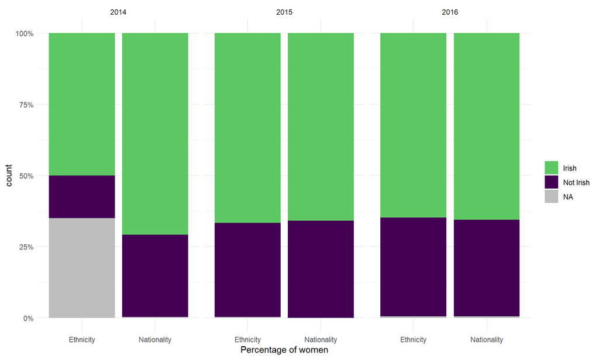

Figure. Ten most common recorded ethnicities

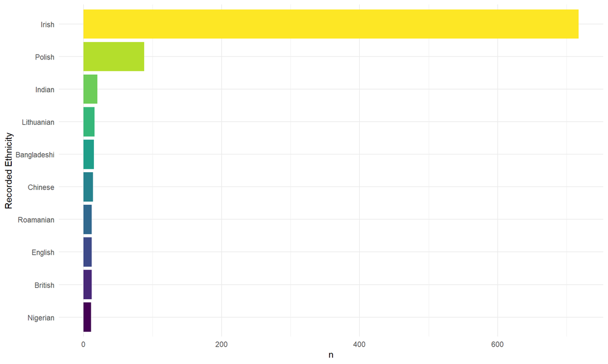

### Risky ethnicity

From https://www.hse.ie/eng/health/az/d/diabetes,-gestational/diagnosing-gestational-diabetes-.html

Your family origins are South Asian (specifically India, Pakistan or Bangladesh), black Caribbean or Middle Eastern (specifically Saudi Arabia, United Arab Emirates, Iraq, Jordan, Syria, Oman, Qatar, Kuwait, Lebanon or Egypt)

Note: I have also included all the African nations, based on what we did before.

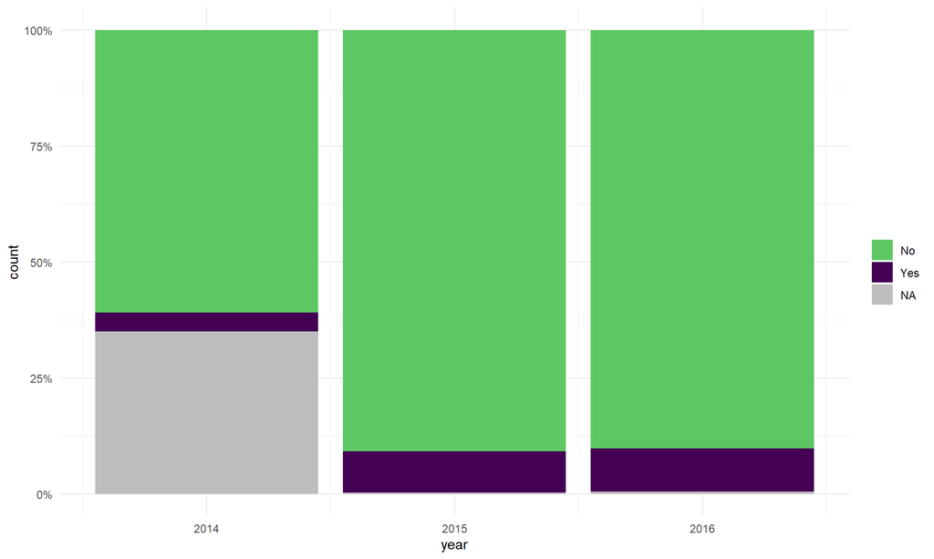

## 2. Age of our mothers any change over 3 years

Missing values for maternal age: 2016 - 1/ 418 ; 2015 - 5 / 369 ; 2014 - 2 / 394 ;

#### Figure. Maternal age distribution by year

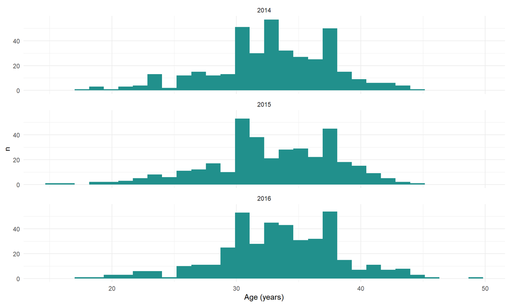

#### Table. Regression of mean age on year.

Fitting linear model: age ~ factor(year)

|  | Estimate | Std. Error | t value | Pr(>\|t\|) |
| --- | --- | --- | --- | --- |
| **(Intercept)** | 32.92 | 0.2476 | 132.9 | 0 |
| **factor(year)2015** | -0.003728 | 0.3569 | -0.01045 | 0.9917 |
| **factor(year)2016** | 0.5542 | 0.3449 | 1.607 | 0.1083 |

The mean age in 2016 is a touch higher, partly driven by a small uptick in the moms over 40 years of age.

Figure. Percentage of moms over 40 years of age.

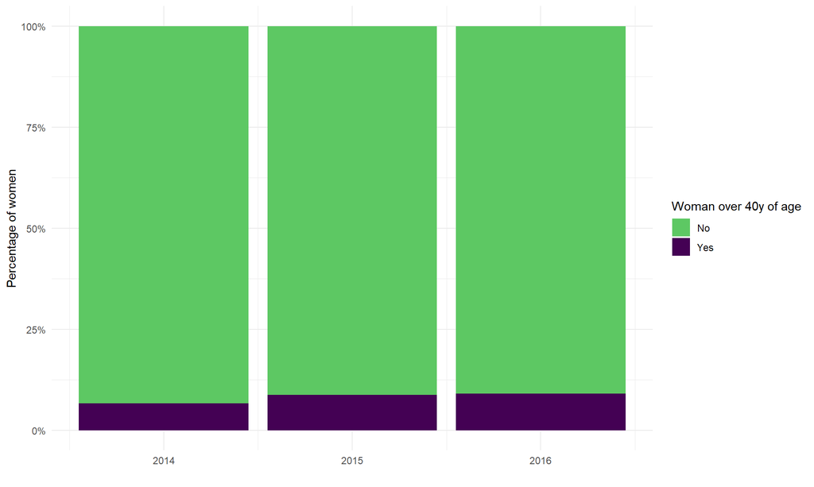

Pearson’s Chi-squared test: `table(data$year, data$over_40)` No strong evidence of a change over years.

| Test statistic | df | P value |
| --- | --- | --- |
| 1.913 | 2 | 0.3843 |

## BMI - again any change over 3 years (where available for full group look at weight gain in pregnancy and any link with outcomes/infant size, delivery method, sub-group where body composition was available any link any associations)

Missing values for BMI: 2016 - 5/ 418 ; 2015 - 4 / 369 ; 2014 - 8 / 394 ;

Figure. BMI distribution by year

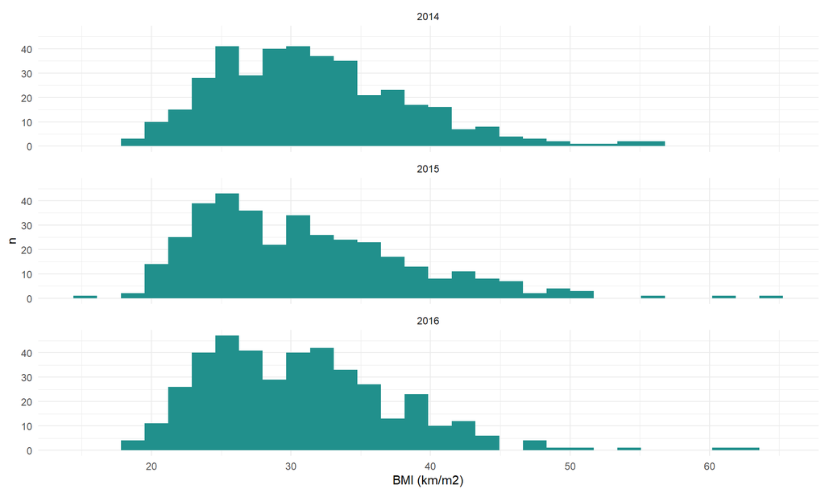

Table. Regression of mean log(bmi) on year.

Fitting linear model: log(bmi) ~ factor(year)

|  | Estimate | Std. Error | t value | Pr(>\|t\|) |
| --- | --- | --- | --- | --- |
| **(Intercept)** | 3.429 | 0.01116 | 307.2 | 0 |
| **factor(year)2015** | -0.02803 | 0.01601 | -1.751 | 0.08029 |
| **factor(year)2016** | -0.02947 | 0.01552 | -1.898 | 0.05788 |

Figure. Percentage of moms at each BMI category.

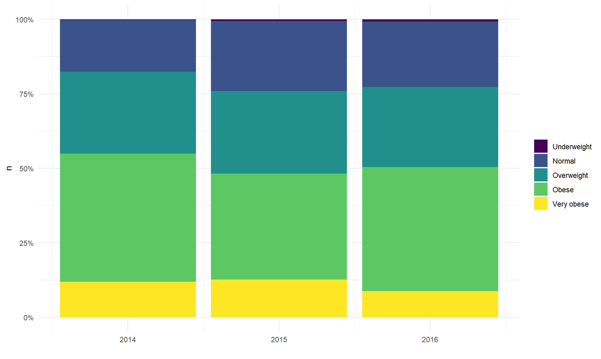

Figure. % body fat distribution by year

Missing BF values = 1095 / 1181.

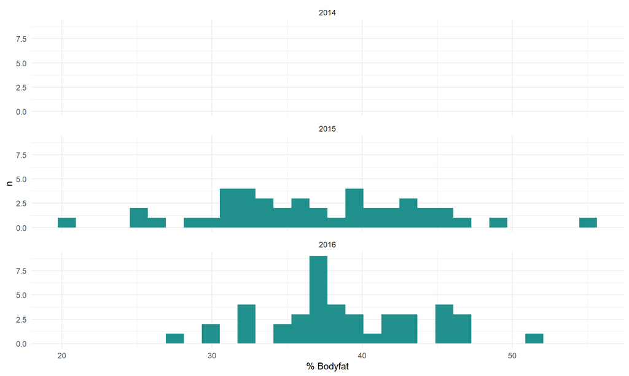

## Gestational Week of GDM diagnosis

Missing values for gestational week of GDM diagnosis: 2016 - 4/ 418 ; 2015 - 4 / 369 ; 2014 - 5 / 394 ;

In the future, these values should be entered into 2 columns, Week and Day, rather than “Week+Day”.

#### Figure. Distribution of gestational week of GDM diagnosis by year

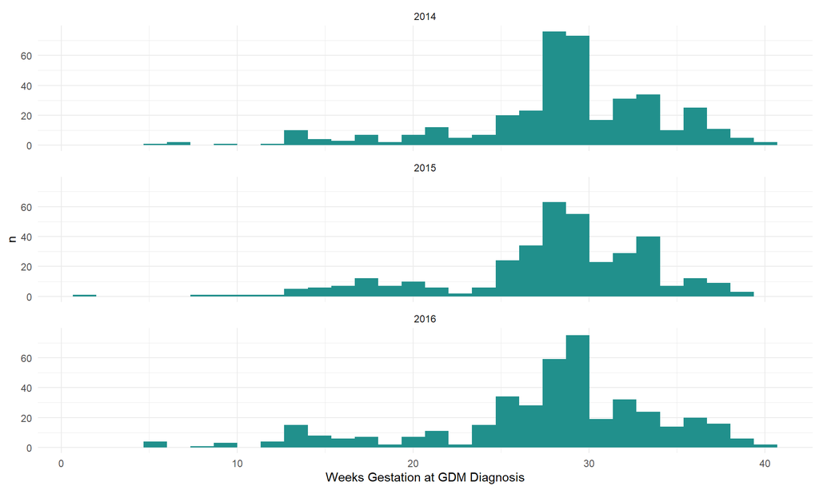

#### Figure. Percentage of women diagnosed with GDM after week 30, by year

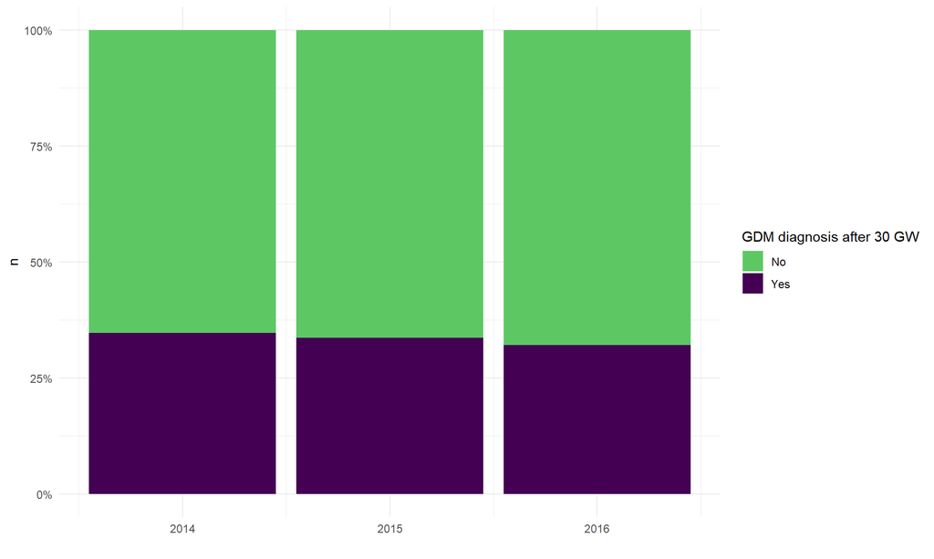

Missing values for GTT location: 2016 - 8/ 418 ; 2015 - 21 / 369 ; 2014 - 16 / 394 ;

#### Figure. Distribution of gestational week of GDM diagnosis by location

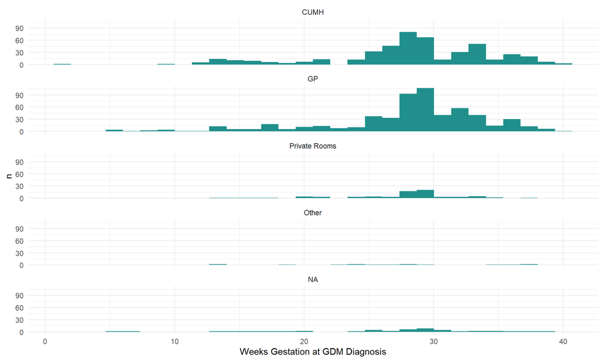

#### Figure. Percentage of women diagnosed with GDM after week 30, by location of GTT

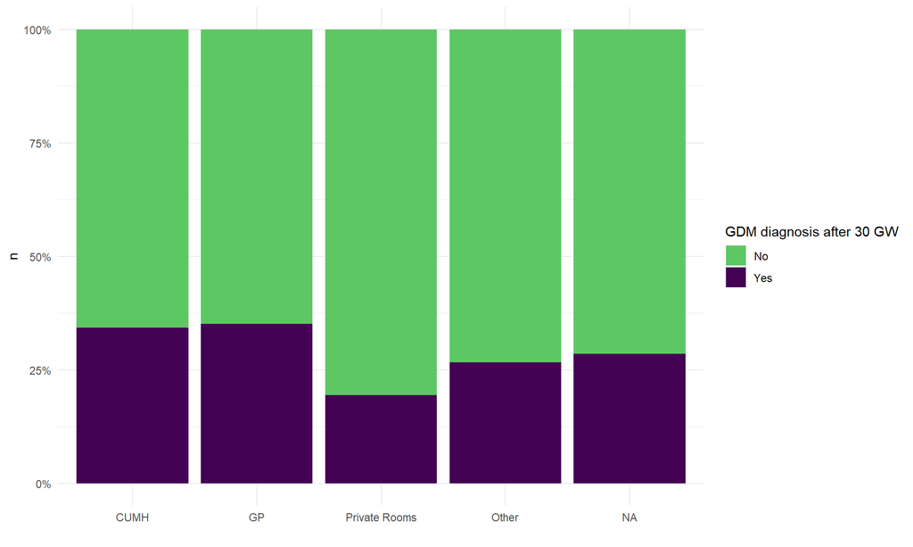

## 7. Mean week of delivery (for whole group, any change over the years)

#### Figure. Weeks gestation at delivery

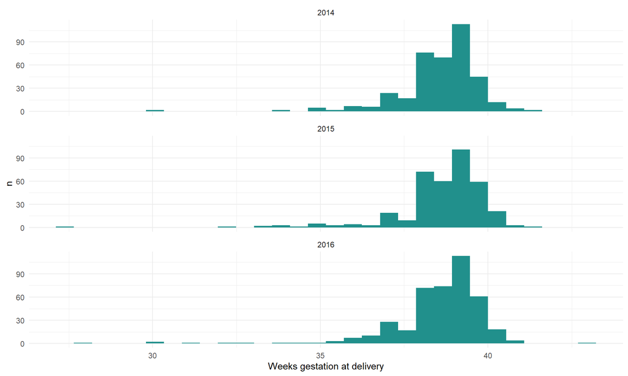

## Appendix 1 - Ethnicity and Nationality

### Ethnicity/Nationality

#### Figure. Recorded ethnicities

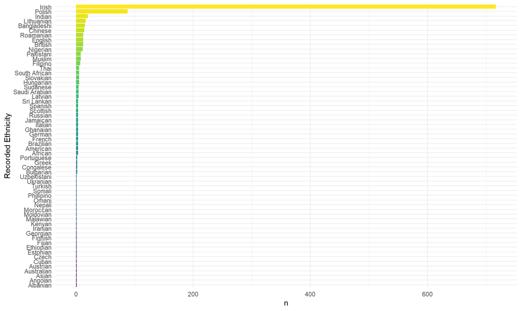

Table. Recorded ethnicities

| Var1 | Freq |
| --- | --- |
| African | 3 |
| Albanian | 1 |
| American | 3 |
| Angolan | 1 |
| Asian | 1 |
| Australian | 1 |
| Austrian | 1 |
| Bangladeshi | 15 |
| Brazilian | 3 |
| British | 12 |
| Bulgarian | 2 |
| Chinese | 14 |
| Congalese | 2 |
| Cuban | 1 |
| Czech | 1 |
| English | 12 |
| Estonian | 1 |
| Ethiopian | 1 |
| Fijian | 1 |
| Filipino | 7 |
| Finnish | 1 |
| French | 3 |
| Georgian | 1 |
| German | 3 |
| Ghanaian | 3 |
| Greek | 2 |
| Hungarian | 5 |
| Indian | 20 |
| Iranian | 1 |
| Irish | 717 |
| Italian | 3 |
| Jamaican | 3 |
| Kenyan | 1 |
| Latvian | 4 |
| Lithuanian | 16 |
| Malawian | 1 |
| Moldovian | 1 |
| Moroccan | 1 |
| Muslim | 8 |
| Nepali | 1 |
| Nigerian | 11 |
| Omani | 1 |
| Pakistani | 8 |
| Phillipino | 1 |
| Polish | 88 |
| Portuguese | 2 |
| Roamanian | 12 |
| Russian | 3 |
| Saudi Arabian | 4 |
| Scottish | 3 |
| Slovakian | 5 |
| Somali | 1 |
| South African | 5 |
| Spanish | 3 |
| Sri Lankan | 3 |
| Sudanese | 4 |
| Thai | 5 |
| Turkish | 1 |
| Ukranian | 1 |
| Uzbekistani | 1 |

#### Table. Recorded nationalities

| Var1 | Freq |
| --- | --- |
| afghanistan | 1 |
| african | 1 |
| albanian | 1 |
| american | 6 |
| angolan | 1 |
| armenian | 1 |
| australian | 1 |
| austrian | 1 |
| bangaladesh | 1 |
| bangladehi | 1 |
| bangladesh | 2 |
| bangladeshi | 16 |
| brazilian | 4 |
| british | 15 |
| bulgaria | 1 |
| bulgarian | 2 |
| chech republic | 1 |
| chinese | 13 |
| congalese | 1 |
| congo | 1 |
| congolese | 1 |
| congolise | 1 |
| congonese | 1 |
| cork | 9 |
| crotian | 1 |
| cuban | 1 |
| czech | 1 |
| english | 16 |
| estonian | 1 |
| ethiopian | 1 |

[output cut: 61 more lines]